# IS608_HW4 slides

```python
import pandas as pd
```

First we load the data

```python
river_entero = pd.read_csv('data/riverkeeper_data_2013.csv')
```

```python
river_entero[10:20]
```

|  | Site | Date | EnteroCount | FourDayRainTotal | SampleCount |
| --- | --- | --- | --- | --- | --- |
| 10 | Hudson above Mohawk River | 6/16/2012 | 10 | 0.2 | 35 |
| 11 | Hudson above Mohawk River | 5/20/2012 | 11 | 0.0 | 35 |
| 12 | Hudson above Mohawk River | 6/24/2013 | 30 | 1.4 | 35 |
| 13 | Hudson above Mohawk River | 9/19/2011 | 11 | 0.1 | 35 |
| 14 | Hudson above Mohawk River | 8/21/2011 | 231 | 0.4 | 35 |
| 15 | Hudson above Mohawk River | 7/14/2011 | 11 | 0.3 | 35 |
| 16 | Hudson above Mohawk River | 7/2/2011 | 11 | 2.1 | 35 |
| 17 | Hudson above Mohawk River | 5/19/2011 | 91 | 1.6 | 35 |
| 18 | Hudson above Mohawk River | 10/16/2010 | >2420 | 1.3 | 35 |
| 19 | Hudson above Mohawk River | 9/14/2010 | 15 | 0.0 | 35 |

```python
river_entero.dtypes
```

```
Site                 object
Date                 object
EnteroCount          object
FourDayRainTotal    float64
SampleCount           int64
dtype: object
```

We need to convert Date and EnteroCount into datetime and float, respectively.

```python
river_entero['Date'] = pd.to_datetime(river_entero['Date'])
```

Let's take a look at which values are 'non-numeric' before conversion.

```python
# create dataframe indexed on datetime to compare pre- and post-conversion
river_entero.sort('Date', inplace=True)
ent_ct = river_entero[['Date', 'EnteroCount']].set_index(river_entero['Date'])['EnteroCount']
converted = ent_ct.convert_objects(convert_numeric=True)

combined = pd.DataFrame(data={'raw': ent_ct, 'converted': converted})
```

If we just drop NaN, we lose ~20% of our sample:

```python
float(converted.count()) / river_entero.shape[0]
```

```
0.8083603179275831
```

So which values are problematic specifically? How can we avoid losing observations?

```python
pd.unique(combined[combined['converted'].isnull()]['raw'].values)
```

```
array(['<10', '>24196', '<1', '>2420'], dtype=object)
```

Is 2420 or 24196 the correct maximum?

```python
converted.max()
```

```
24196.0
```

Did the metric change from >2420 to >24196? (Seems suspicious, given how similar these caps look.)

A visualization will help.

```python
import vincent
vincent.core.initialize_notebook()

correct_max = vincent.Line(converted.dropna())
correct_max.display()
```

Looks like the correct cap is >24196. Let's convert these to 24196 so we can convert them to numeric. All the mins will be converted to 0.

```python
river_entero['EnteroCount'].replace(to_replace='[>].*', value = '24196', regex=True, inplace=True)
river_entero['EnteroCount'].replace(to_replace='[<].*', value = '0', regex=True, inplace=True)

river_entero['EnteroCount'] = river_entero['EnteroCount'].convert_objects(convert_numeric=True)
```

Let's make sure everything looks right.

```python
river_entero.describe()
```

|  | EnteroCount | FourDayRainTotal | SampleCount |
| --- | --- | --- | --- |
| count | 3397.000000 | 3397.000000 | 3397.000000 |
| mean | 764.391816 | 0.568001 | 56.886370 |
| std | 3717.785705 | 1.000387 | 41.588476 |
| min | 0.000000 | 0.000000 | 27.000000 |
| 25% | 4.000000 | 0.000000 | 37.000000 |
| 50% | 18.000000 | 0.200000 | 42.000000 |
| 75% | 85.000000 | 0.700000 | 50.000000 |
| max | 24196.000000 | 8.500000 | 187.000000 |

## Create lists and graphs of the best and worst places to swim in the dataset.

```python
by_site = river_entero[['Site', 'EnteroCount']].groupby('Site')
```

```python
# summarize by location
worst_places = by_site.mean()
worst_places.columns = ['Mean_ent',]
worst_places['Median_ent'] = by_site.median()
worst_places['Max_ent'] = by_site.max()
worst_places['Min_ent'] = by_site.min()
worst_places['SD'] = by_site.std()

# sort on mean
worst_places.sort(columns=['Mean_ent',], ascending=False, inplace=True)
sample_count = river_entero[['Site', 'SampleCount']].groupby('Site').sum()
worst_places['Samples'] = sample_count
```

```python
best_places = worst_places.tail(5)
best_places.head()
```

| Site | Mean_ent | Median_ent | Max_ent | Min_ent | SD | Samples |
| --- | --- | --- | --- | --- | --- | --- |
| TZ Bridge mid-channel | 15.473684 | 0.0 | 252 | 0 | 45.605884 | 3249 |
| Haverstraw Bay mid-channel | 13.500000 | 0.0 | 164 | 0 | 29.709229 | 2304 |
| Stony Point mid-channel | 12.795455 | 1.5 | 196 | 0 | 31.993153 | 1936 |
| Croton Point Beach | 10.666667 | 2.0 | 169 | 0 | 25.485359 | 2304 |
| Poughkeepsie Drinking Water Intake | 8.210526 | 4.5 | 76 | 0 | 13.011757 | 1444 |

```python
worst_places = worst_places.head(5)
worst_places.head()
```

| Site | Mean_ent | Median_ent | Max_ent | Min_ent | SD | Samples |
| --- | --- | --- | --- | --- | --- | --- |
| Gowanus Canal | 4204.945946 | 96 | 24196 | 0 | 8563.134291 | 1369 |
| Upper Sparkill Creek | 3935.587879 | 411 | 24196 | 3 | 8143.522629 | 27225 |
| Newtown Creek- Metropolitan Ave. Bridge | 2952.280702 | 98 | 24196 | 0 | 7399.631778 | 3249 |
| Island Creek/Normans Kill | 2298.342857 | 46 | 24196 | 2 | 6815.557398 | 1225 |
| Tarrytown Marina | 2204.185185 | 41 | 24196 | 0 | 6426.040365 | 729 |

Places we probably would not want to swim.

```python
# chart worst places
bar_groups = vincent.GroupedBar(worst_places[['Mean_ent', 'Median_ent']])
bar_groups.axis_titles(x='Location', y='Value')
bar_groups.legend(title='Statistics')
bar_groups.display()
```

Places we probably wouldn't want to swim in, but probably won't get sick if we absolutely had to.

```python
# chart worst places
bar_groups = vincent.GroupedBar(best_places[['Mean_ent', 'Median_ent']])
bar_groups.axis_titles(x='Location', y='Value')
bar_groups.legend(title='Statistics')
bar_groups.display()
```

## Which sites have been tested most regularly? Which ones have long gaps between tests?

```python
freq = river_entero
freq.set_index(keys=[river_entero['Site'], river_entero['Date']], inplace=True, verify_integrity=True)
freq.head()
```

| Site | Date | Site | Date | EnteroCount | FourDayRainTotal | SampleCount |
| --- | --- | --- | --- | --- | --- | --- |
| Furnace Brook | 2006-09-19 | Furnace Brook | 2006-09-19 | 28 | 0 | 48 |
| Haverstraw Bay mid-channel | 2006-09-19 | Haverstraw Bay mid-channel | 2006-09-19 | 4 | 0 | 48 |
| Ossining Beach | 2006-09-19 | Ossining Beach | 2006-09-19 | 2 | 0 | 47 |
| Croton Point Beach | 2006-09-19 | Croton Point Beach | 2006-09-19 | 2 | 0 | 48 |
| Stony Point mid-channel | 2006-09-19 | Stony Point mid-channel | 2006-09-19 | 3 | 0 | 44 |

```python
freq['diffs'] = freq['Date'].groupby(level='Site').diff()

# built-in max() aggregation for dataframes does not work with timedeltas
max_gap = freq['diffs'].dropna().groupby(level='Site').apply(lambda x : x.max())
max_gap.sort(ascending=False)
max_gap.head(5)
```

```
Site
Tarrytown Marina          0   334 days
125th St. Pier            0   291 days
Gowanus Canal             0   281 days
Upper Sparkill Creek      0   280 days
North River STP at 145th  0   256 days
dtype: timedelta64[ns]
```

```python
# combine max gap + samples
samples = freq['SampleCount'].groupby(level='Site').mean()
# shape (75, 1) -> (75,) to match samples
max_gap = max_gap.unstack(1).ix[:, 0]
# DataFrame doesn't like nanoseconds
max_gap = max_gap.astype('timedelta64[D]').astype(int)
max_gap = DataFrame(data={'samples': samples, 'gap': max_gap}, index=samples.index)
```

```python
# store only those with the largest gaps
max_gap = max_gap.sort(columns='gap', ascending=False)
max_gap.head()
```

| Site | gap | samples |
| --- | --- | --- |
| Tarrytown Marina | 334 | 27 |
| 125th St. Pier | 291 | 66 |
| Gowanus Canal | 281 | 37 |
| Upper Sparkill Creek | 280 | 165 |
| East River mid-channel at 23rd St. | 256 | 50 |

```python
# chart most sporadically tested & least sporadically tested
stack = vincent.StackedBar(
    max_gap[(max_gap['gap'] > 256) | (max_gap['gap'] < 225)]
)
stack.scales['x'].padding = 0.1
stack.axis_titles(x='Location', y='')
stack.axes[0].properties = vincent.AxisProperties(
    labels = vincent.PropertySet(angle=vincent.ValueRef(value=10))
)
stack.legend(title='Data Type')
stack.colors(brew='Spectral')
stack.display()
```

Perhaps surprisingly, there is not such a large amount variation among sites a one might think.

## Is there a relationship between the amount of rain and water quality?

```python
corr = lambda x : ()
rain_cor = freq[['EnteroCount', 'FourDayRainTotal']].groupby(level='Site').corr()
rain_cor.head()
```

| Site |  | EnteroCount | FourDayRainTotal |
| --- | --- | --- | --- |
| 125th St. Pier | EnteroCount | 1.000000 | 0.155190 |
|  | FourDayRainTotal | 0.155190 | 1.000000 |
| 79th St. mid-channel | EnteroCount | 1.000000 | 0.193267 |
|  | FourDayRainTotal | 0.193267 | 1.000000 |
| Albany Rowing Dock | EnteroCount | 1.000000 | 0.368754 |

```python
# rather have single column with all the location-specific correlations
rain_cor = rain_cor.ix[:, 'EnteroCount'].ix[:, 'FourDayRainTotal']
rain_cor.sort(ascending=False)

print 'Highest linear relationship between rain & entero'
print rain_cor.head()
print '\nLowest linear relationship between rain & entero'
print rain_cor.tail()
```

```
Highest linear relationship between rain & entero
Site
Gay's Point mid-channel     0.729229
The Battery mid-channel     0.708365
Wappingers Creek            0.687614
TZ Bridge mid-channel       0.672044
Norrie Point Yacht Basin    0.663862
Name: EnteroCount, dtype: float64

Lowest linear relationship between rain & entero
Site
Yonkers mid-channel          -0.068253
Kingston STP Outfall         -0.083880
Mohawk River at Waterford    -0.124760
Little Stony Point           -0.158027
Haverstraw Bay mid-channel   -0.160901
Name: EnteroCount, dtype: float64
```

Some areas have very strong linkages between rainfall and entero counts; however, some areas appear to have almost no relationship (possibly even a negative relationship)!

Let's see how the relationship varies across location:

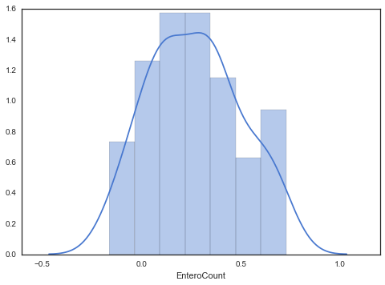

```python
import numpy as np
import matplotlib.pyplot as plt
import seaborn as sns

# want to plot in-line
%matplotlib inline

sns.set(style='white', palette='muted')
plt.figure(1)
sns.distplot(rain_cor)
plt.show()
```

It appears as if generally speaking, rainfall and entero count are positively correlated, with the mean level of correlation around 0.25.

To generalize the relationship across locations, we can try to visualize the scatter plot and marginal distributions:

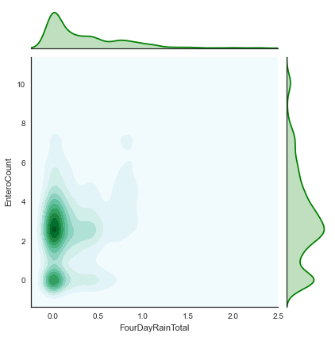

```python
# take log transform of entero count and rain since highly skewed
from math import log
from scipy import stats
log_ent = freq['EnteroCount'].map(lambda x : log(x + 1))
log_rain = freq['FourDayRainTotal'].map(lambda x : log(x + 1))

g = sns.JointGrid(log_rain, log_ent)
g.plot_marginals(sns.kdeplot, shade=True, color='green')
g.plot_joint(sns.kdeplot, shade=True)
```

A clear linear relationship isn't particularly evident from this graphic. At the end of the day, this is logical--different locations will have very different characteristics and we should avoid abstracting away location-specific factors that may exert an important influence over entero count and how it fluctuates with rainfall.